# 03_BRTs_examples

```r
library(dplyr)
library(ggplot2)
library(parallel)
library(gbm)
library(dismo)
library(forcats)
library(fastshap)
library(shapviz)
library(caret)

set.seed(24) # for example consistency
```

# 1 Coding implementations of boosted regression trees (BRTs)

We’ll use the `gbm` package via the `dismo` package to build BRTs.

`dismo`’s `gbm.step` function has a convenient, built-in k-fold cross-validation that tunes the number of trees based on the learning rate, tree complexity, and bag fraction, and calculates some performance metrics for the folds.

Boosted regression trees (and other boosted models) are also found in other packages (including `caret` and `parsnip`), but we’ll stick with `dismo` and `gbm` here.

# 2 Building a BRT - bike sharing example

For this example, we downloaded data from a Kaggle machine learning competition. The dataset contains data on daily bike sharing rental counts for 2011 and 2012 from the Capital Bikeshare system in Washington, D.C. Also included in the dataset are columns containing information on the seasonality (month, season), weather (temperature, precipitation), type of day (holiday, weekend, etc.). See the dataset readme (`/data/bike_share_readme.txt`) for full column descriptions.

Our task is to predict bike rental counts based on the season, weather, and type of day.

```r
bike_share_day <- read.csv(here::here("data", "bike_share_day.csv"))
str(bike_share_day)
```

```
'data.frame':   731 obs. of  16 variables:
 $ instant   : int  1 2 3 4 5 6 7 8 9 10 ...
 $ dteday    : chr  "2011-01-01" "2011-01-02" "2011-01-03" "2011-01-04" ...
 $ season    : int  1 1 1 1 1 1 1 1 1 1 ...
 $ yr        : int  0 0 0 0 0 0 0 0 0 0 ...
 $ mnth      : int  1 1 1 1 1 1 1 1 1 1 ...
 $ holiday   : int  0 0 0 0 0 0 0 0 0 0 ...
 $ weekday   : int  6 0 1 2 3 4 5 6 0 1 ...
 $ workingday: int  0 0 1 1 1 1 1 0 0 1 ...
 $ weathersit: int  2 2 1 1 1 1 2 2 1 1 ...
 $ temp      : num  0.344 0.363 0.196 0.2 0.227 ...
 $ atemp     : num  0.364 0.354 0.189 0.212 0.229 ...
 $ hum       : num  0.806 0.696 0.437 0.59 0.437 ...
 $ windspeed : num  0.16 0.249 0.248 0.16 0.187 ...
 $ casual    : int  331 131 120 108 82 88 148 68 54 41 ...
 $ registered: int  654 670 1229 1454 1518 1518 1362 891 768 1280 ...
 $ cnt       : int  985 801 1349 1562 1600 1606 1510 959 822 1321 ...
```

Let’s clean this up a little bit, so we don’t have all of the extra columns in the way.

```r
bike_df <- bike_share_day |>
  # select just the desired columns and rename count
  dplyr::select(instant, dteday, season, mnth,
                holiday, weekday, workingday, weathersit,
                temp, atemp, hum, windspeed, "count" = cnt) |>

  # translate some columns back to words, make factors factors, re-scale var's
  dplyr::mutate(
    season = as.factor(dplyr::case_when(
      season == 1 ~ "Spring",
      season == 2 ~ "Summer",
      season == 3 ~ "Autumn",
      season == 4 ~ "Winter"
    )),

    weathersit = as.factor(dplyr::case_when(
      weathersit == 1 ~ "Clear",
      weathersit == 2 ~ "Cloudy",
      weathersit == 3 ~ "Light precip",
      weathersit == 4 ~ "Heavy precip"
    )),

    mnth = as.factor(mnth),

    weekday = as.factor(weekday),

    workingday = as.factor(workingday),

    holiday = as.factor(holiday),

    # put 0-1 normalized var's back to previous scales based on `data/bike_share_readme.txt`
    temp = temp * 41, # was normalized by max
    atemp = atemp * 50, # was normalized by max
    hum = hum * 100, # was normalized by max (now percent)
    windspeed = windspeed * 67 # was normalized by max
  )
```

## 2.1 Handling correlated predictors

```r
possible_predictors <- c("season", "mnth", "holiday", "weekday",
                         "workingday", "weathersit", "temp",
                         "atemp", "hum", "windspeed")

# get just the numeric predictors
numeric_predictors_df <- bike_df |>
  dplyr::select(dplyr::any_of(possible_predictors)) |>
  # just the numeric cols
  dplyr::select(dplyr::where(is.numeric))
names(numeric_predictors_df)
```

```
[1] "temp"      "atemp"     "hum"       "windspeed"
```

Calculating a correlation for categorical variables is more complicated, so we’re going to skip that for now. But for numeric variables we can use `caret`’s `findCorrelation` function to identify which variables should be excluded based on a provided correlation cutoff (we’ll use 0.9 here).

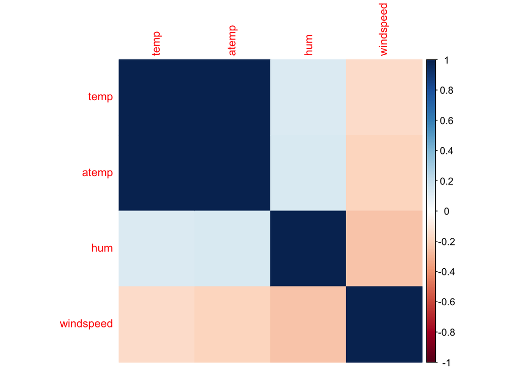

```r
# calculate correlation coefficient
corr_mat <- cor(numeric_predictors_df, use = "complete.obs")

# visualize the correlations
corrplot::corrplot(corr_mat, method = "color", tl.cex = 0.9)
```

```r
# identify which variables to exclude
corr_var_indx <- caret::findCorrelation(corr_mat, cutoff = 0.9)

# var's to be removed:
num_vars_to_remove <- names(numeric_predictors_df)[corr_var_indx]
num_vars_to_remove
```

```
[1] "atemp"
```

Now we have a set of numeric variables that are not correlated more than a 0.9 (absolute value) with one another, which should help a bit with interpretation later.

We’ll also take a look at the categorical variables to see if there are any variables we’d like to exclude. Note that we’ll do this qualitatively for this example, but there are ways to formally do this as well.

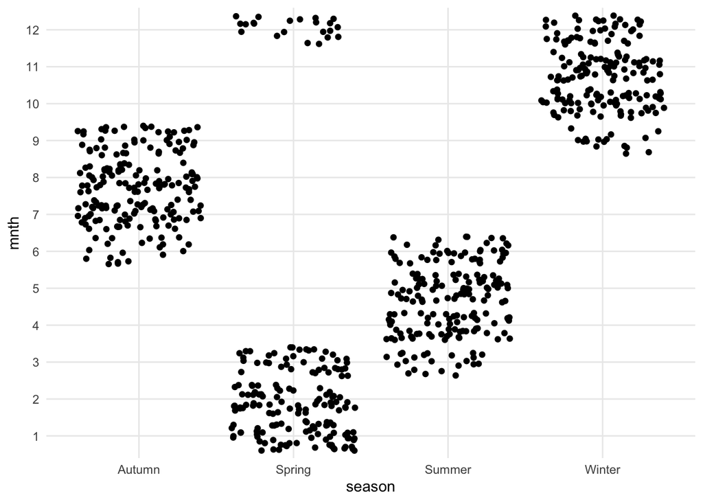

```r
# Month and season
bike_df |>
  dplyr::select(dplyr::any_of(possible_predictors)) |>
  # just the factors
  dplyr::select(dplyr::where(is.factor)) |>
  ggplot(aes(x = season, y = mnth)) +
  geom_jitter() +
  theme_minimal()
```

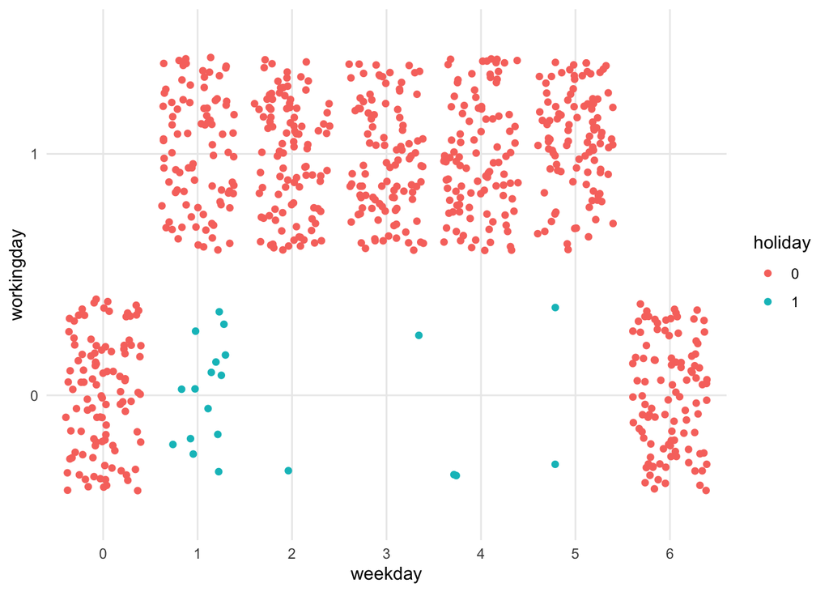

```r
# weekday and working day
bike_df |>
  dplyr::select(dplyr::any_of(possible_predictors)) |>
  # just the factors
  dplyr::select(dplyr::where(is.factor)) |>
  ggplot(aes(x = weekday, y = workingday, color = holiday)) +
  geom_jitter() +
  theme_minimal()
```

These variable combinations are inherently connected to one another, so for our purposes we’ll use just the month (exclude season) and just the working day column (exclude weekday and holiday). Depending on your specific purpose, you could make these decisions differently, but we’ll just go with this for now.

```r
cat_vars_toremove <- c("season", "weekday", "holiday")

# make vector of final predictors
predictors_tomod <- bike_df |>
  dplyr::select(dplyr::any_of(possible_predictors)) |>
  dplyr::select(-dplyr::any_of(num_vars_to_remove),
                -dplyr::any_of(cat_vars_toremove)) |>
  names()
```

## 2.2 Model tuning

With BRTs (or any boosted models), model tuning is especially important to avoid over-fitting. So we need to make sure we try multiple hyper-parameters to find a good model.

Before we get to it, a reminder on the links between the hyperparameters in the BRTs algorithm…

`learning_rate` is the influence any one tree has on the final prediction. The smaller this number, the more trees required for good fits and the more trees required to over-fit. **Rule of thumb**: somewhere between 0.1 for large, complex datasets to 0.00001 or smaller for small datasets.

`tree_complexity` is the tree depth of the individual trees. Deeper trees overfit more quickly, but shallow trees can require large numbers of trees to be built. **Rule of thumb**: shallow trees work well, usually 1 to 10 is a good range to explore.

`bag_fraction` is the percent of the dataset that is considered for each tree (in each bag). For small datasets, should be kept larger. **Rule of thumb**: try 0.5, 0.625, and 0.75 for most datasets, if it’s really small can go up to 0.9

`number_of_trees` is the number of individual trees that are built. The `gbm.step` function in the `dismo` package automatically tunes this one based on the three others, and this one becomes secondary to the other three for most applications. **Rule of thumb**: Models that build at least 1000 trees tend to be best, but those that build at least 500 could be fine too. Models with many more trees (10,000+) may be unnecessarily restrained (and slow) unless the dataset is very large.

The learning rate, tree complexity, and number of trees are highly inter-connected. A model that has a high learning rate with high tree complexity will overfit with just a small number of trees. Increasing the tree complexity should probably correspond with a decrease in the learning rate if you’re seeking similar performance. In practice with grid-search tuning, we’ll explore all the combinations, but some of those combinations are much less likely to be the best model because of these links.

To determine the set of hyper-parameters to consider, you can either:

- Build all models from a very wide range of hyper-parameters, which may take a lot of computational time.
- Build an “un-tuned” model using trial and error to see how many trees are built, then selecting a range around the values that worked.

Before the workshop, we used the second option to figure out a reasonable set of values to use :).

### 2.2.1 First, let’s look at an example model run, without tuning

So we don’t get lost in the weeds before we start, let’s build a preliminary model first, without tuning the hyper-parameters. This will let us see the code and details of the model building. In the next section, we’ll do grid-search tuning.

```
 GBM STEP - version 2.9

Performing cross-validation optimisation of a boosted regression tree model
for NA and using a family of poisson
Using 731 observations and 6 predictors
creating 10 initial models of 50 trees

 folds are unstratified
total mean deviance =  914.9122
tolerance is fixed at  0.9149
ntrees resid. dev.
50    600.5905
now adding trees...
100   478.1447
150   421.6899
200   388.1346
250   370.4375
300   360.0952
350   353.9392
400   350.5017
450   347.948
500   345.9593
550   345.1644
600   344.9777
650   344.9051
700   344.8204
750   344.8385
800   345.2355
850   345.3183
900   346.1451
950   346.3649
1000   346.8664
1050   346.9753
1100   347.2388
1150   346.9124
1200   347.4583
1250   347.9908
1300   348.286
```

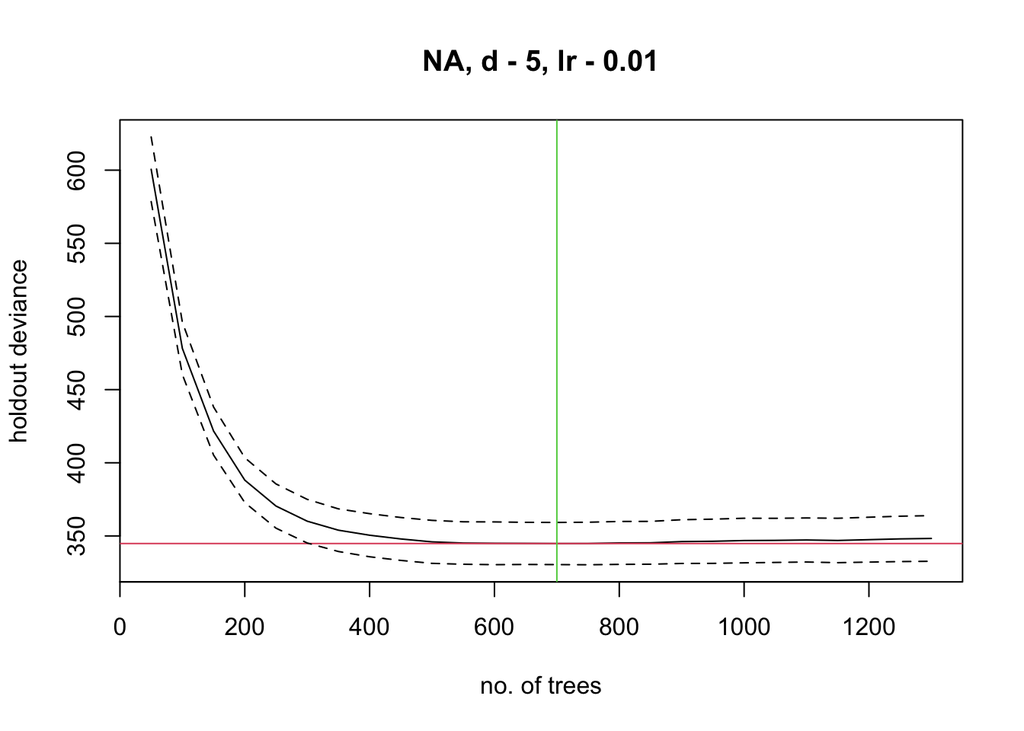

```
fitting final gbm model with a fixed number of 700 trees for NA
```

```
mean total deviance = 914.912
mean residual deviance = 235.414

estimated cv deviance = 344.82 ; se = 14.402

training data correlation = 0.864
cv correlation =  0.788 ; se = 0.011

elapsed time -  0.06 minutes
```

```r
mod_ex <- dismo::gbm.step(
  data = bike_df,

  # colnames of predictors
  gbm.x = predictors_tomod,

  # colname of response
  gbm.y = "count",

  # wts vector
  site.weights = rep(1, nrow(bike_df)), # no weights applicable here, so all 1 (default)

  # mod specs
  family = "poisson", # our response is count data, see ?gbm for the options
  tree.complexity = 5,
  learning.rate = 0.01,
  bag.fraction = 0.5,
  max.trees = 10000 # avoid long runs
)
```

```r
mod_ex$cv.statistics
```

```
$deviance.mean
[1] 344.8204

$deviance.se
[1] 14.40175

$correlation.mean
[1] 0.7875939

$correlation.se
[1] 0.01077636

$discrimination.mean
[1] 0

$discrimination.se
[1] 0

$calibration.mean
[1] 3.460951e-02 9.962559e-01 1.934009e-14 8.527790e-12 2.385175e-03

$calibration.se
[1] 2.698554e-01 3.141859e-02 1.934009e-14 7.682095e-12 2.305959e-03
```

Feel free to explore the `mod_ex` model object a bit more on your own, or keep going to get into the model tuning.

### 2.2.2 Model tuning for our example

First, we’ll set up the range of hyper-parameters we’ll consider. Here, we’re mostly considering a range of tree complexity, with the others set as just two options, for the sake of computational time.

```r
learning_rate <- c(0.01, 0.001)
tree_complexity <- c(1, 3, 5, 7, 9)
bag_fraction <- c(0.5, 0.75)
```

Once we select the hyper-parameters we’ll consider, we need to do some setup so that we can do our model tuning efficiently.

```r
full_params_list <-
  # get every combo of params
  expand.grid(
    learning_rate = learning_rate,
    bag_fraction = bag_fraction,
    tree_complexity = tree_complexity
  ) |>

  # set up output col's
  dplyr::mutate(ntrees = NA, dev_mean = NA, dev_se = NA) |>
  dplyr::mutate(row_id = dplyr::row_number()) |>

  # split into list for parallel processing
  dplyr::group_split(row_id, .keep = FALSE)
```

#### Parallel processing (optional; not run on render)

**Description and code for parallel processing**

Now, we’ll use the following code to make the tuning process run in parallel. It gets a little less fun to read, so the steps are outlined here first.

- Determine the number of cores (parallel threads) you want to use
- Make a function that builds a model for each combo of hyperparameters. This will be applied to each element of the `full_params_list`. We’re calling it `mod_fun`.
- Setup an empty cluster
- Use `parallel::parLapply()` to apply the `mod_fun` function using the cluster
- When it’s done, stop the cluster
- Bind the results together

#### Determining number of cores

Before we continue, here’s some code that helps determine the number of cores you have available on your machine.

You can use this code to see how many cores R has access to.

```r
parallel::detectCores()
```

Then you can change the `ncores` number below as you wish to change the number of cores used in the tuning process.

#### Now doing the grid-search tuning in parallel

First, we’ll setup the function that allows us to build the model in parallel. It’s a basic wrapper around the `dismo::gbm.step()` function that we’ll use to build the final model after tuning.

```r
# model-making function to parallelize
mod_fun <- function(
    spec_df, # spec_df is from the parameters
    mod_df, # mod_df is the training data
    pred_colnames, # character vector of predictor column names
    response_colname, # response column name
    wts_colname = NULL, # column name for weights, if applicable
    family, # family supplied to gbm, see ?gbm distribution argument
    max_trees = 10000, # maximum number of trees, useful as a cutoff to avoid long runs
    silent
) {

  if (is.null(wts_colname)) {
    wts = rep(1, nrow(mod_df))
  } else {
    wts = mod_df[[wts_colname]]
  }

  # build model
  mod <- dismo::gbm.step(
    data = mod_df,

    # colnames of predictors
    gbm.x = pred_colnames,

    # colname of response
    gbm.y = response_colname,

    # wts vector
    site.weights = wts,

    # mod specs
    family = family,
    tree.complexity = spec_df$tree_complexity,
    learning.rate = spec_df$learning_rate,
    bag.fraction = spec_df$bag_fraction,
    max.trees = max_trees,

    # prevent long messages and plots while running
    silent = silent,
    plot.main = FALSE
  )

  # retrieve performance specs
  spec_df$ntrees <- mod$n.trees
  spec_df$dev_mean <- mod$cv.statistics$deviance.mean
  spec_df$dev_se <- mod$cv.statistics$deviance.se

  spec_df
}
```

Then we’ll setup the number of cores and run the tuning.

```r
# set number of cores
ncores <- 5

# Initialize a cluster with the specified number of cores
cl <- parallel::makeCluster(
  # take the minimum here to safely not use too many cores
  min(ncores, parallel::detectCores(), length(full_params_list))
  )

# Apply function in parallel using parLapply
par_list <- parallel::parLapply(
  cl,
  X = full_params_list, # each element of this list becomes spec_df for mod_fun
  fun = mod_fun,
  mod_df = bike_df,
  pred_colnames = predictors_tomod,
  response_colname = "count",
  wts_colname = NULL,
  family = "poisson",
  max_trees = 10000, # maximum number of trees, useful as a cutoff to avoid long runs
  silent = TRUE
)

# stop the cluster when done
parallel::stopCluster(cl)

# bind rows into data frame
tune_df <- dplyr::bind_rows(par_list)

# sort by mean deviance and view
tune_df |>
  dplyr::arrange(dev_mean)
```

#### Model tuning in loop form

To avoid some of the complications of parallel computing for this workshop, we’ll use a loop. The max trees here is set to 2000 trees so that the runtime doesn’t take too long, but in practice this is pretty limiting. A max of 5,000 or 10,000 trees is a better rule of thumb to balance efficiency with identifying a top model.

This tuning step should take less than 2 minutes with a max of 2000 trees; it takes about 4 minutes with a max of 10,000 trees (but can multiply much more for complicated models or large datasets).

```r
tune_res_list <- list()
for (i in seq_len(length(full_params_list))) {

  spec_df <- full_params_list[[i]]

  # build model
  mod <- dismo::gbm.step(
    data = bike_df,

    # colnames of predictors
    gbm.x = predictors_tomod,

    # colname of response
    gbm.y = "count",

    # mod specs
    family = "poisson",
    tree.complexity = spec_df$tree_complexity,
    learning.rate = spec_df$learning_rate,
    bag.fraction = spec_df$bag_fraction,
    max.trees = 2000, # max 2000 trees to avoid long run times in loop

    # prevent long messages and plots while running
    silent = TRUE,
    plot.main = FALSE
  )

  # retrieve performance specs
  spec_df$ntrees <- mod$n.trees
  spec_df$dev_mean <- mod$cv.statistics$deviance.mean
  spec_df$dev_se <- mod$cv.statistics$deviance.se

  tune_res_list[[i]] <- spec_df

}

tune_df <- dplyr::bind_rows(tune_res_list)

tune_df |>
  dplyr::arrange(dev_mean)
```

```
# A tibble: 20 × 6
   learning_rate bag_fraction tree_complexity ntrees dev_mean dev_se
           <dbl>        <dbl>           <dbl>  <dbl>    <dbl>  <dbl>
 1         0.01          0.5                9    500     343.   16.0
 2         0.01          0.75               5    700     344.   14.1
 3         0.01          0.5                5    750     345.   13.9
 4         0.01          0.5                7    550     345.   12.3
 5         0.01          0.75               7    500     347.   16.2
 6         0.01          0.75               9    500     350.   17.3
 7         0.01          0.5                3   1650     350.   14.9
 8         0.01          0.75               3    950     353.   22.0
 9         0.001         0.75               9   2000     364.   16.0
10         0.01          0.75               1   1900     366.   20.8
11         0.01          0.5                1   2000     368.   16.6
12         0.001         0.5                9   2000     368.   14.8
13         0.001         0.5                7   2000     374.   19.1
14         0.001         0.75               7   2000     376.   21.3
15         0.001         0.5                5   2000     387.   19.6
16         0.001         0.75               5   2000     392.   20.7
17         0.001         0.5                3   2000     417.   21.5
18         0.001         0.75               3   2000     420.   26.4
19         0.001         0.5                1   2000     502.   27.3
20         0.001         0.75               1   2000     503.   39.2
```

This data frame provides us the model performance for each combination of hyper-parameters. The `dismo::gbm.step` uses the mean deviance as the measure to minimize for number of trees, so it also makes sense to use that one in this tuning step.

**Note**

Note that some (many) of the combinations built the maximum number of trees, which means that they didn’t finish running before they reach our maximum number of trees. Because they reached the max, they weren’t evaluated at their best, just their best under the maximum number of trees.

If you were prioritizing comparing each combination of the parameters, you’d probably want to increase the maximum number of trees.

If you were prioritizing efficiency, you might not care if some of those models reached the max. Especially if it’s likely to have similar performance to a parameter combination that builds a smaller number of trees and is therefore faster.

Now, we select the “best” one, but the best one isn’t necessarily the combination with the lowest mean deviance. You can look at the standard error of the deviance measure to see that many of the top combinations are performing similarly. It is then up to the modeler to make the final selection of the hyper-parameters that make the most sense.

This can feel like more of an art than a science, but there are some rules of thumb that we’ve used at this stage.

1. “Enough” trees is subjective, but at least 1000 trees is a good benchmark.
2. Almost always, you should select a combination that performs “equally” well when considering the standard error of the deviance.
3. Generally, models with tree complexity greater than 1 are probably better if you think there are likely interactions between variables.

#### Building the final model

Now let’s build the selected model:

```
 GBM STEP - version 2.9

Performing cross-validation optimisation of a boosted regression tree model
for NA and using a family of poisson
Using 731 observations and 6 predictors
creating 10 initial models of 50 trees

 folds are unstratified
total mean deviance =  914.9122
tolerance is fixed at  0.9149
now adding trees...
```

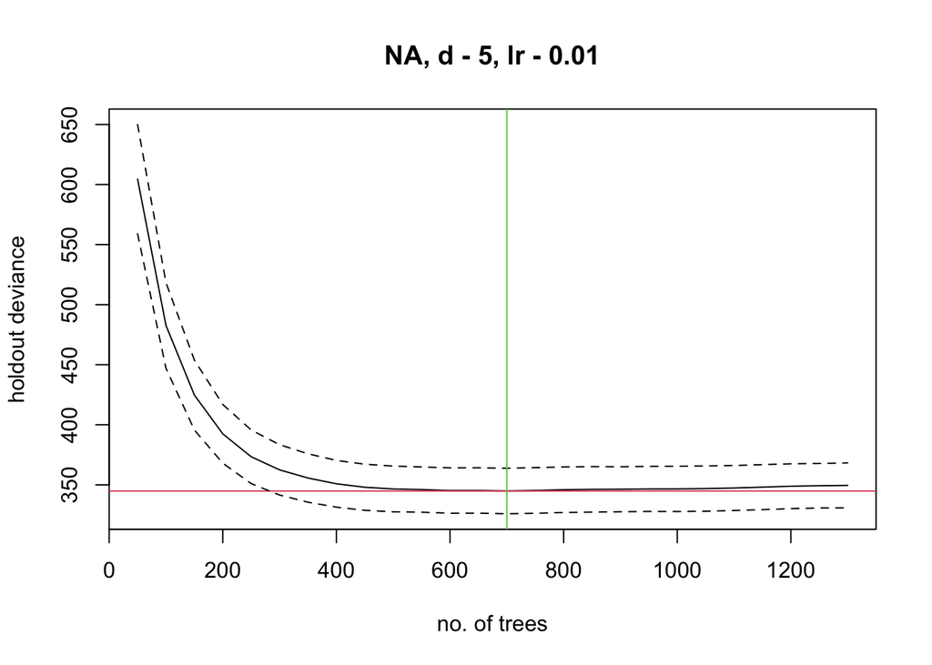

```
fitting final gbm model with a fixed number of 700 trees for NA
```

```r
lr <- 0.01
tc <- 5
bf <- 0.75

bike_mod_full <- dismo::gbm.step(
    data = bike_df,

    # colnames of predictors
    gbm.x = predictors_tomod,

    # colname of response
    gbm.y = "count",

    # wts vector
    site.weights = rep(1, nrow(bike_df)),

    # mod specs
    family = "poisson",
    tree.complexity = tc,
    learning.rate = lr,
    bag.fraction = bf,
    max.trees = 10000,
    verbose = FALSE
  )
```

```r
bike_mod_full$cv.statistics
```

```
$deviance.mean
[1] 344.8626

$deviance.se
[1] 18.96436

$correlation.mean
[1] 0.7861038

$correlation.se
[1] 0.008879113

$discrimination.mean
[1] 0

$discrimination.se
[1] 0

$calibration.mean
[1] 0.09521344 0.98896910 0.00000000 0.00000000 0.13932561

$calibration.se
[1] 0.34131973 0.03955561 0.00000000 0.00000000 0.09800189
```

**Thinking question:**

Currently, we’re using the internal cross-validation in `dismo::gbm.step` to evaluate this model, which limits us a bit on the metric we can use (only deviance and correlation easily available, though we could manually calculate others), and limits any structuring of the cross-validation.

How would you ideally evaluate this model to predict the future year’s demand?

## 2.3 Basic model interpretation

Variable importance is calculated as the percent relative influence for BRTs. The sum across all variables is equal to 100%. The variable importance measure is found in the model object.

```r
bike_mod_full$contributions
```

```
                  var    rel.inf
temp             temp 59.2568978
hum               hum 16.7422867
mnth             mnth 12.9847101
windspeed   windspeed  7.7342060
weathersit weathersit  2.5466236
workingday workingday  0.7352758
```

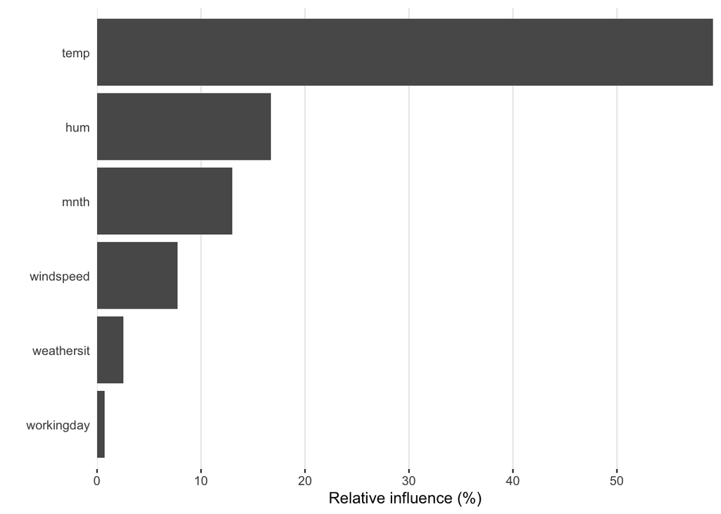

```r
# plotting them (nicely) with ggplot
bike_mod_full$contributions |>
  dplyr::mutate(var = forcats::fct_reorder(var, rel.inf)) |>
  ggplot(aes(x = rel.inf, y = var)) +
  geom_col() +
  labs(x = "Relative influence (%)", y = "") +
  scale_x_continuous(expand = c(0, NA)) +
  theme_bw() +
  theme(panel.grid.minor = element_blank(),
        panel.grid.major.y = element_blank(),
        axis.ticks.y = element_blank(),
        panel.border = element_blank())
```

We can also use a built-in function from `dismo` to make the partial dependence plots.

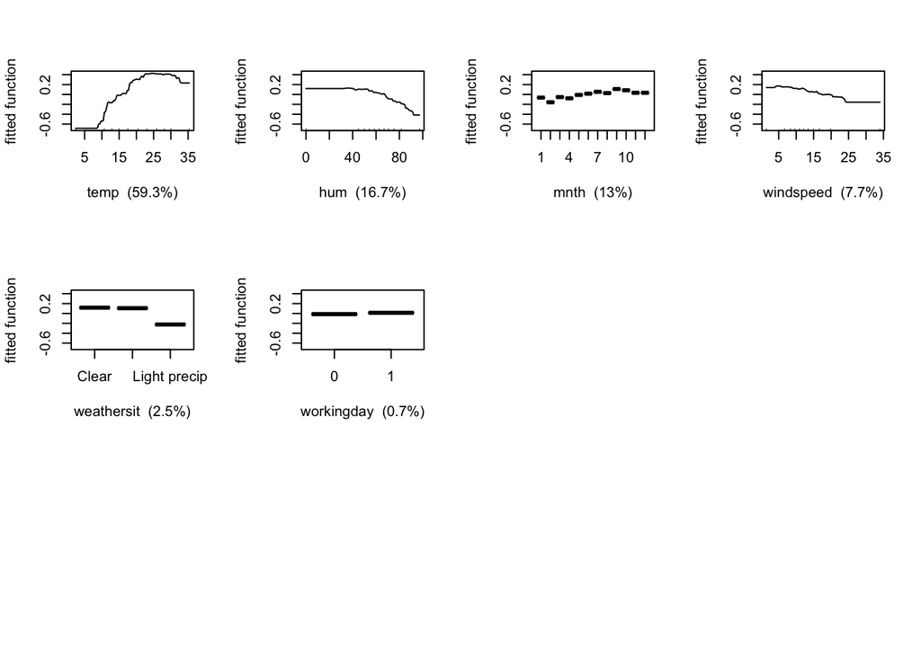

```r
dismo::gbm.plot(gbm.object = bike_mod_full)
```

# 3 Deeper model interpretation via SHAP values

SHapley Additive exPlanation (SHAP) values measure the contribution of each variable to the model’s prediction, for *individual rows*.

They tell us which variables drive (increase or decrease) an individual prediction of a model. By summarizing them in different ways (see below for some possibilities), we can identify how the variables are informing the model predictions at a fine scale.

“Shapley” and “SHAP” are sometimes used interchangeably, but SHAP values refers to the machine learning technique that calculates the Shapley values described in game theory. There is a [freely available book chapter](https://christophm.github.io/interpretable-ml-book/shapley.html) focused on SHAP values, and a [book called “Interpreting machine learning methods with SHAP” by C. Molnar](https://christophmolnar.com/books/shap) that contains many more details (and python examples).

Many R packages can calculate SHAP values, including those in the following table, with comparisons provided by Claude. Note that the method of SHAP value calculation/approximation varies among different approaches and that’s beyond this workshop.

| R package | [`iml`](https://christophm.github.io/iml/) | [`fastshap`](https://bgreenwell.github.io/fastshap/) | [`treeshap`](https://modeloriented.github.io/treeshap/) | [`shapr`](https://norskregnesentral.github.io/shapr/) |
| --- | --- | --- | --- | --- |
| **Method** | Monte Carlo | Monte Carlo | Exact TreeSHAP | Conditional |
| **Speed** | Slow | Medium | Fast | Medium |
| **Model-agnostic** | ✅ | ✅ | ❌ (trees only) | ✅ |
| **Handles correlation** | ❌ | ❌ | ❌ | ✅ |
| **Built-in plots** | ✅ | ✅ | ✅ | ✅ |
| **Batch inference** | Manual loop | ✅ | ✅ | ✅ |

We’ll use `fastshap` because it’s not limited to tree-based methods (so it’s better if you want to take this approach to another model type) and it’s faster than `iml`. We’ve used `iml` in projects before, but the runtime can be somewhat lengthy.

## 3.1 SHAP values for our bike sharing example

To start, we have to make a “prediction function” that the `fastshap` will use. It’s very basic, but a necessary component:

```r
pred_fun <- function(object, newdata) {
  suppressMessages(
    predict(object, newdata = newdata)
  )
}
```

Then we can actually calculate the SHAP values using the `explain` function from `fastshap`. Note that in the `X` argument, we can only supply variables that were actually predictors in our `bike_mod_full`. We’ll use 20 in the `nsim` argument for the sake of time today, but 100 is probably a better rule of thumb.

We’re going to calculate the SHAP values for all rows of our training data, but in other projects it might make sense to calculate SHAP values for only a subset, or for some data outside the training data. All are possible, but if you’re using summaries of SHAP values, you need to make sure you understand which set of rows they were calculated for.

```r
# Calculate SHAP values for all rows
shap_fastshap <- fastshap::explain(
  object = bike_mod_full,
  X = bike_df |>
    dplyr::select(dplyr::any_of(predictors_tomod)),
  pred_wrapper = pred_fun,
  shap_only = FALSE,
  nsim = 20,  # number of Monte Carlo repetitions
)

str(shap_fastshap)
```

```
List of 3
 $ shapley_values: num [1:731, 1:6] -0.16 -0.113 -0.14 -0.118 -0.133 ...
  ..- attr(*, "dimnames")=List of 2
  .. ..$ : NULL
  .. ..$ : chr [1:6] "mnth" "workingday" "weathersit" "temp" ...
 $ feature_values:'data.frame': 731 obs. of  6 variables:
  ..$ mnth      : Factor w/ 12 levels "1","2","3","4",..: 1 1 1 1 1 1 1 1 1 1 ...
  ..$ workingday: Factor w/ 2 levels "0","1": 1 1 2 2 2 2 2 1 1 2 ...
  ..$ weathersit: Factor w/ 3 levels "Clear","Cloudy",..: 2 2 1 1 1 1 2 2 1 1 ...
  ..$ temp      : num [1:731] 14.11 14.9 8.05 8.2 9.31 ...
  ..$ hum       : num [1:731] 80.6 69.6 43.7 59 43.7 ...
  ..$ windspeed : num [1:731] 10.7 16.7 16.6 10.7 12.5 ...
 $ baseline      : num 0
 - attr(*, "class")= chr "explain"
```

For visualization, you can work with the values in the object directly, or use the `shapviz` package like we’ll use below. We’ll start by making a `shapviz` object from our results.

```r
# Convert to shapviz object
sv <- shapviz(
  shap_fastshap,
  X = bike_df
)
```

### 3.1.1 Plotting SHAP values

There are *many* potential ways to visualize SHAP values.

We’re going to look at them in a few different ways:

1. First we’ll look at the SHAP values for a single day, to get an idea of what the values actually mean.
2. Then we’ll look at some overall summaries that can give us overall trends (similar to variable importance plots from before, but with some more detail).
3. Then we’ll look at a couple example SHAP dependence plots that let you dive a bit deeper into how the model is using the data to make predictions.

#### Single day SHAP values

We’ll do a little coding to help us match up the date to the SHAP results.

```r
# checkout a single date that you specify yourself
date_of_interest <- "2012-01-30"

# sv only includes the cols in shap_fastshap, so we'll make a look-up table for rows
# instant is effectively the row number that was supplied to shapviz, so we'll use that to go between dates and the shap results
row_of_interest <- bike_df |>
  dplyr::select(instant, dteday) |>
  dplyr::filter(dteday == date_of_interest) |>
  dplyr::pull(instant)
```

Then we can look at plots of the SHAP values for that day. First, we’ll look at a plot that we build manually using the values in the `sv` object.

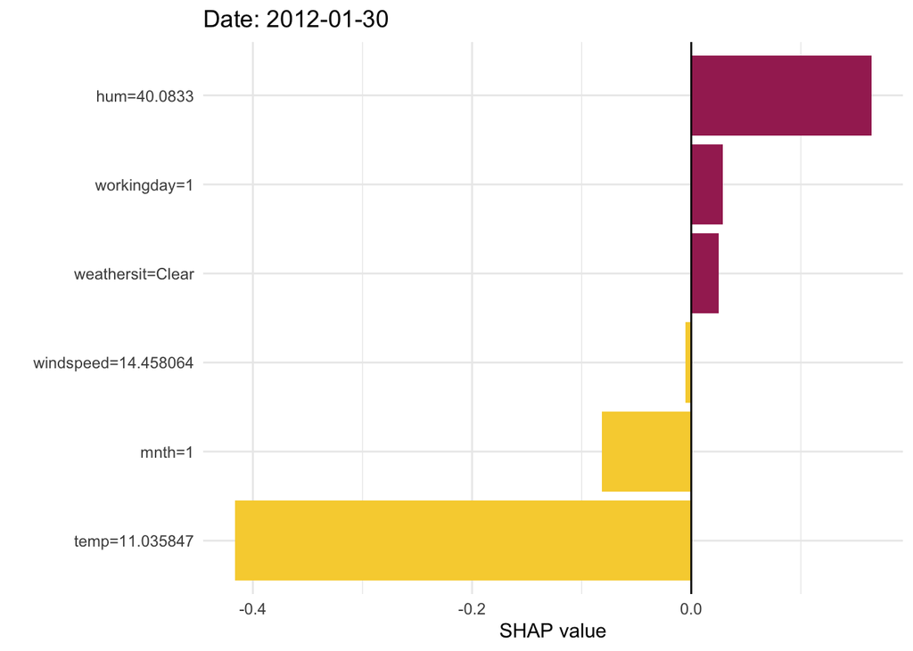

```r
# get the feature vals
feat_vals <- sv$X |>
  as.data.frame() |>
  # add row id and pivot longer
  dplyr::mutate(rownum = dplyr::row_number()) |>
  # make everything a character before pivoting
  dplyr::mutate(across(everything(), as.character)) |>
  tidyr::pivot_longer(cols = !rownum,
                      names_to = "feature",
                      values_to = "feature_value")
# get the shap vals
shap_vals <- sv$S |>
  as.data.frame() |>
  # add row id and pivot longer
  dplyr::mutate(rownum = as.character(dplyr::row_number())) |>
  tidyr::pivot_longer(cols = !rownum,
                      names_to = "feature",
                      values_to = "SHAP")

# join shap with feature vals for plotting
toplot_vals <- shap_vals |>
  dplyr::left_join(feat_vals,
                   by = c("rownum", "feature"))

# plot the shap vals with feature vals labeled for context
toplot_vals |>
  dplyr::filter(rownum == row_of_interest) |>
  # paste values to make y-labels
  dplyr::mutate(
    feature_label = paste0(feature, "=", feature_value)
  ) |>
  # re-order factor for plotting
  dplyr::mutate(
    feature_label = forcats::fct_reorder(feature_label, SHAP)
  ) |>
  ggplot() +
  geom_col(aes(x = SHAP, y = feature_label, fill = sign(SHAP)),
           show.legend = FALSE) +
  geom_vline(xintercept = 0) +
  scale_fill_gradient2(low = "#f7d13d", mid = "white", high = "#a52c60") +
  labs(y = "", x = "SHAP value", title = paste0("Date: ", date_of_interest)) +
  theme_minimal()
```

Positive SHAP values indicate when the feature value for this date *increased* the predicted number of bike rentals, negative SHAP values indicate when the feature value for this date *decreased* the predicted number of bike rentals. The observed feature value for each feature gets a SHAP value, and each date gets a full set of SHAP values.

For this date, temperature is substantially decreasing the predicted number of rentals, while the observed humidity is increasing the predicted number of rentals.

SHAP values across all variables add up to the difference between the average predicted value across the training data and the predicted value for this individual date.

So the net result here is that the observed values are decreasing the predicted number of bike rentals compared to the average number of rentals.

Another way to visualize this is with a “waterfall” plot:

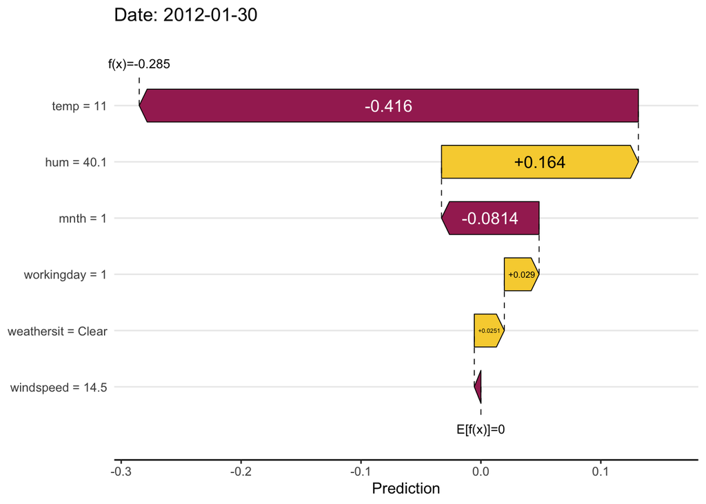

```r
sv_waterfall(sv, row_id = row_of_interest) +
  ggtitle(paste0("Date: ", date_of_interest))
```

Waterfall plots show the same SHAP values, but emphasize the contributed change each variable gives to the final prediction ($f(x)=-0.3$) relative to the average prediction ($E[f(x)]=0$). The final position shows the summed difference (sum of all the SHAP values) from the average prediction on the x axis.

Now, being able to see what variables contributed to individual predictions is super powerful! But in many cases it’s not very feasible to look at those plots for all of the data points…we’d have to look at 700+ plots just for this example! RShiny dashboards that let you toggle through individual rows (whether they be dates or places) could help with that, but next we’ll look at some summaries that give us a bigger picture.

#### Summarizing SHAP values

One of the simplest summaries we can calculate is the mean absolute value of the SHAP values across all rows. This gives us a variable importance measure, but based on the SHAP values (instead of the other ways these algorithms calculate variable importance).

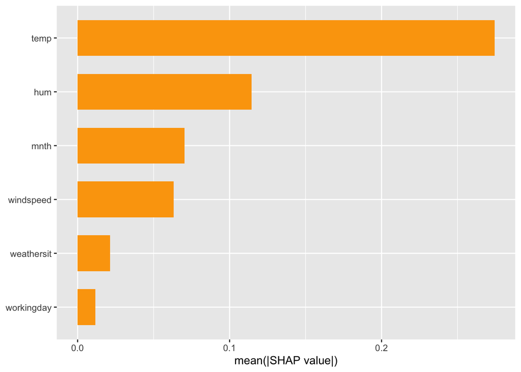

```r
shapviz::sv_importance(sv)
```

Since these bars are summarizing over 700+ dates, we can also separate out some of those SHAP values in a plot called “beeswarm”. It let’s us look at variable importance, but with variability across dates more visible.

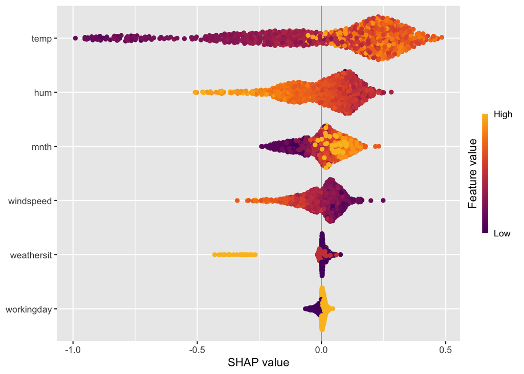

```r
shapviz::sv_importance(sv, kind = "beeswarm")
```

#### SHAP Dependence Plots

We can also visualize the SHAP values alongside the values of the predictors. These are called “SHAP Dependence Plots”, and they serve a similar purpose to partial dependence plots. However, they don’t average across all data points, so they can show interactions and variability. They also don’t operate on the same scale, with SHAP dependence plots using the SHAP value and PDPs using the predicted values.

We’ll look at a few different SHAP dependence plots here:

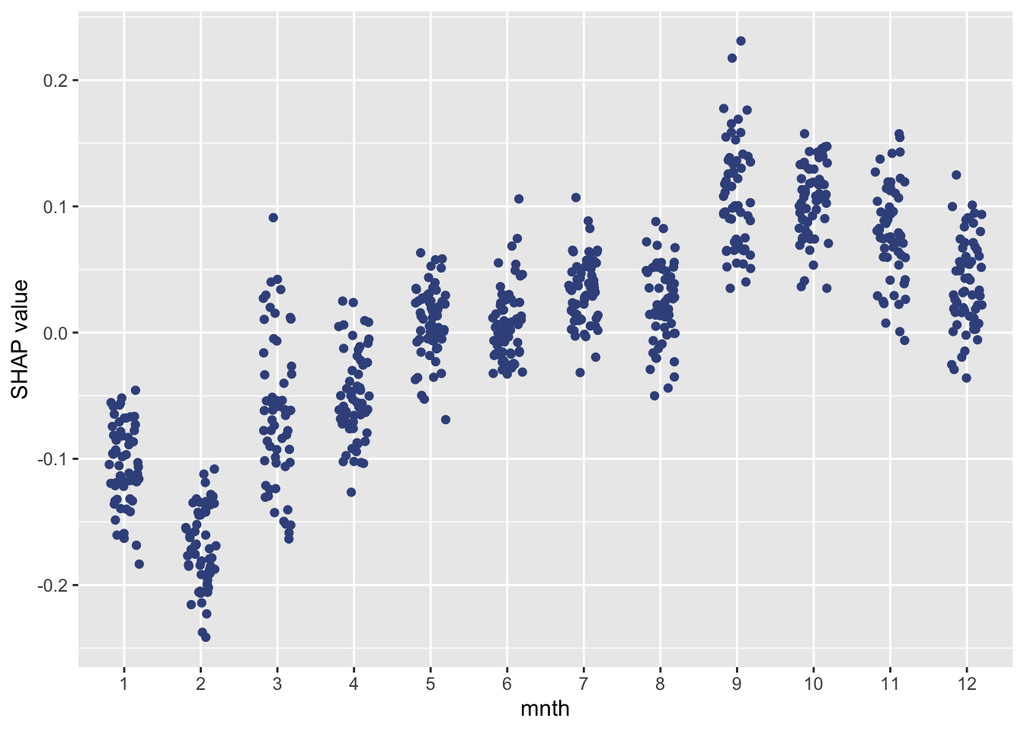

```r
shapviz::sv_dependence(sv, v = "mnth", color_var = NULL)
```

We can also color the points based on another variable for more context. Here, we’ll look at month again but colored by temperature.

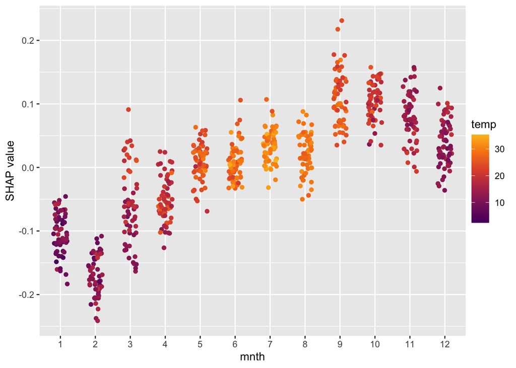

```r
shapviz::sv_dependence(sv, v = "mnth", color_var = "temp")
```

Another option is to plot in 2 dimensions with color representing the summed SHAP value between two variables. This can help visualize interactions, but can also get hard to interpret. We’ll just look at one example for this with temperature and humidity:

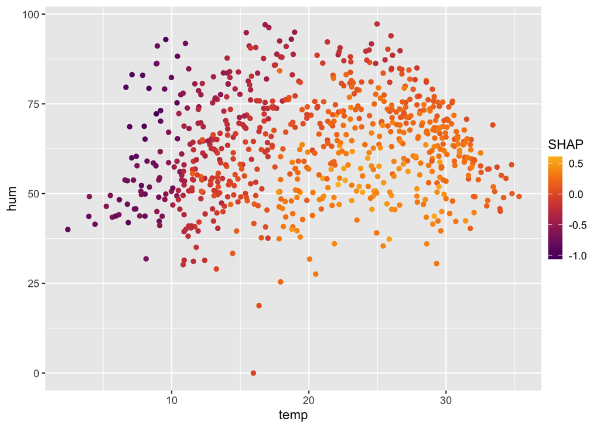

```r
sv_dependence2D(sv, x = "temp", y = "hum")
```